# Network distance

The following is an example of how to calculate network distance in python. I used the following sites as resources to create this:

- https://networkx.github.io/documentation/stable/
- https://automating-gis-processes.github.io/2017/lessons/L7/network-analysis.html

These are the python libraries I will use

```python
import geopandas as gpd
import pandas as pd
import matplotlib.pyplot as plt
import osmnx as ox
import networkx as nx
from shapely.geometry import box, LineString, Point,MultiPoint
import pyproj
import os
import sys
sys.path.append(os.path.realpath('..'))
```

## Open Street Map

- We pull in data from Open Street Map
- Specify that that we will be calculating walking distances

```python
place_name = "New York City, NY, United States of America"
graph = ox.graph_from_place(place_name, network_type='walk')
```

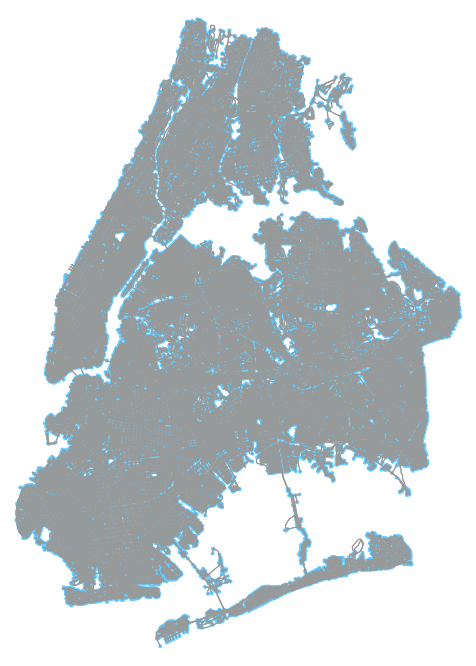

```python
fig, ax = ox.plot_graph(graph, fig_height=12)
```

From the graph, we will extract the nodes and the edges(lines) into geopandas dataframes

```python
nodes, edges = ox.graph_to_gdfs(graph, nodes=True, edges=True)
```

Check the crs of each of them

```python
nodes.crs
```

```
{'init': 'epsg:4326'}
```

```python
edges.crs
```

```
{'init': 'epsg:4326'}
```

Obtain some statistics about the graph we had extracted

```python
stats = ox.basic_stats(graph)
stats
```

```
{'n': 102520,
 'm': 319636,
 'k_avg': 6.235583300819353,
 'intersection_count': 89591,
 'streets_per_node_avg': 3.119761997658993,
 'streets_per_node_counts': {0: 0,
  1: 12929,
  2: 3,
  3: 52635,
  4: 35920,
  5: 889,
  6: 136,
  7: 7,
  8: 1},
 'streets_per_node_proportion': {0: 0.0,
  1: 0.12611197815060476,
  2: 2.926258291065158e-05,
  3: 0.5134120171673819,
  4: 0.3503706593835349,
  5: 0.008671478735856419,
  6: 0.0013265704252828716,
  7: 6.827936012485369e-05,
  8: 9.754194303550527e-06},
 'edge_length_total': 24370226.77800066,
 'edge_length_avg': 76.24368587393366,
 'street_length_total': 12266411.895000145,
 'street_length_avg': 76.47770396902679,
 'street_segments_count': 160392,
 'node_density_km': None,
 'intersection_density_km': None,
 'edge_density_km': None,
 'street_density_km': None,
 'circuity_avg': 1.0425264395549814,
 'self_loop_proportion': 0.0035915854284248334,
 'clean_intersection_count': None,
 'clean_intersection_density_km': None}
```

## Test case

We will use two points that are across from each other, but has a highway between them. The network analysis route should move along the road until it find a road that can cross under the highway.

To see the points: Destination point: https://www.google.com/maps/place/40%C2%B044'13.9%22N+73%C2%B051'50.6%22W/@40.737199,-73.8662467,17z/data=!3m1!4b1!4m5!3m4!1s0x0:0x0!8m2!3d40.737199!4d-73.864058

Origin point: https://www.google.com/maps/place/40%C2%B043'56.9%22N+73%C2%B051'42.0%22W/@40.732484,-73.8638547,17z/data=!3m1!4b1!4m5!3m4!1s0x0:0x0!8m2!3d40.732484!4d-73.861666

```python
target_xy = (40.737199,-73.864058)
orig_xy = (40.732484,-73.861666)
```

For the origin/destination point, we will find the nearest node.

```python
orig_node = ox.get_nearest_node(graph, orig_xy, method='euclidean')
target_node = ox.get_nearest_node(graph, target_xy, method='euclidean')
o_closest = nodes.loc[orig_node]
t_closest = nodes.loc[target_node]
```

```python
route = nx.shortest_path(G=graph, source=orig_node, target=target_node, weight=None)
```

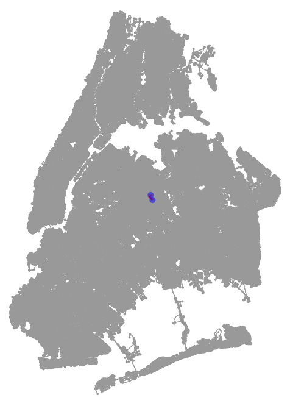

```python
fig, ax = ox.plot_graph_route(graph, route, origin_point=orig_xy, destination_point=target_xy, fig_height=12)
plt.tight_layout();
```

Capture the route nodes and turn it into a `LineString`

```python
route_nodes = nodes.loc[route]
```

```python
route_line = LineString(list(route_nodes.geometry.values))
```

Make a geodataframe to store the data

```python
route_geom = gpd.GeoDataFrame(crs=edges.crs)
route_geom['geometry'] = None
route_geom['osmids'] = None
```

Add the information into the geodataframe

```python
route_geom.loc[0, 'geometry'] = route_line
```

```python
route_geom.loc[0, 'osmids'] = str(list(route_nodes['osmid'].values))
```

Now is the time to convert the data into epsg 2263.

```python
route_geom.crs
```

```
{'init': 'epsg:4326'}
```

```python
route_geom = route_geom.to_crs({'init': 'epsg:2263'})
```

Calculate route length

```python
route_geom['length_ft'] = route_geom.length
```

```python
route_geom['length_miles'] = route_geom['length_ft'] *0.000189394
```

```python
route_geom['length_miles'].head()
```

```
0    0.546331
Name: length_miles, dtype: float64
```

```python
route_geom['id'] = route_geom.index
```

View the route!

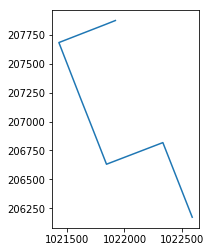

```python
route_geom.plot()
```

```python
route_geom.head()
```

|  | geometry | osmids | length_ft | length_miles | id |
| --- | --- | --- | --- | --- | --- |
| 0 | LINESTRING (1022588.666680825 206166.516154735... | [42814128, 5572315119, 5487756539, 42814124, 3... | 2884.624747 | 0.546331 | 0 |

```python
fp =  r"intermediate_data\test_route_shapefile.shp"
route_geom[['id','geometry']].to_file(fp)
```